# Анализ Выживаемости: дз

Author

Воронин Кирилл

## 1. Импорт данных и составление выборки

- **Задача 1:** Загрузите csv файл, созданный в `homework-data.qmd`

```r
data <- read.csv("data.csv")
```

## 2. Кривые Каплана–Майера

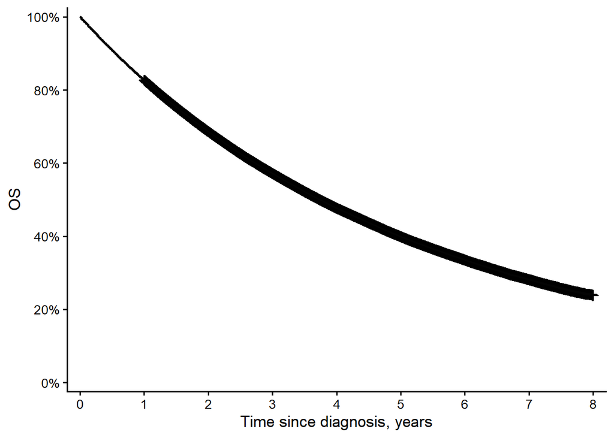

```r
fit <- survfit2(Surv(time, status) ~ 1, data)
fit_cens <- survfit2(Surv(time, abs(status - 1)) ~ 1, data)

ggsurvfit(fit, linewidth = 1) +
  add_censor_mark(stroke = 1) +
  add_confidence_interval(alpha = 0.08) +
  scale_ggsurvfit(
    y_scales = list(breaks = seq(0, 1, 0.2))
  ) +
  theme_classic(base_size = 13) +
  labs(x = "Time since diagnosis, years", y = "OS")
```

```r
tbl_survfit(
  fit,
  probs = 0.5,
  statistic = "{estimate}",
  label_header = "median surv, years"
)
```

| **Characteristic** | median surv, years |
| --- | --- |
| Overall | 3.7 |

```r
tbl_survfit(
  fit_cens,
  probs = .5,
  statistic = "{estimate}",
  label_header = "median, years"
)
```

| **Characteristic** | median, years |
| --- | --- |
| Overall | 4.5 |

```r
tbl_survfit(fit, times = c(1, 3, 4), label_header = "{time}y", label = "OS")
```

| **Characteristic** | 1y | 3y | 4y |
| --- | --- | --- | --- |
| OS | 83% (83%, 83%) | 57% (57%, 57%) | 48% (47%, 48%) |

- **Задача 2.2: Сравнение кривых по вмешательству и числу лейкоцитов.**
1. Постройте на одном графике кривые Каплана–Майера для `surgery = 0` и `surgery = 1` по всей выборке. Добавьте 95%-е доверительные интервалы и таблицу числа пациентов под риском.
2. Разделите пациентов на две подгруппы по числу лейкоцитов: `wbc <= 100` и `wbc > 100`. В каждой подгруппе постройте кривые для `surgery = 0` и `surgery = 1` с 95%-ми доверительными интервалами и таблицей числа пациентов под риском. Покажите результаты на двух графиках, на одном графике с двумя панелями (facet_wrap) или на одном графике с четырьмя кривыми.

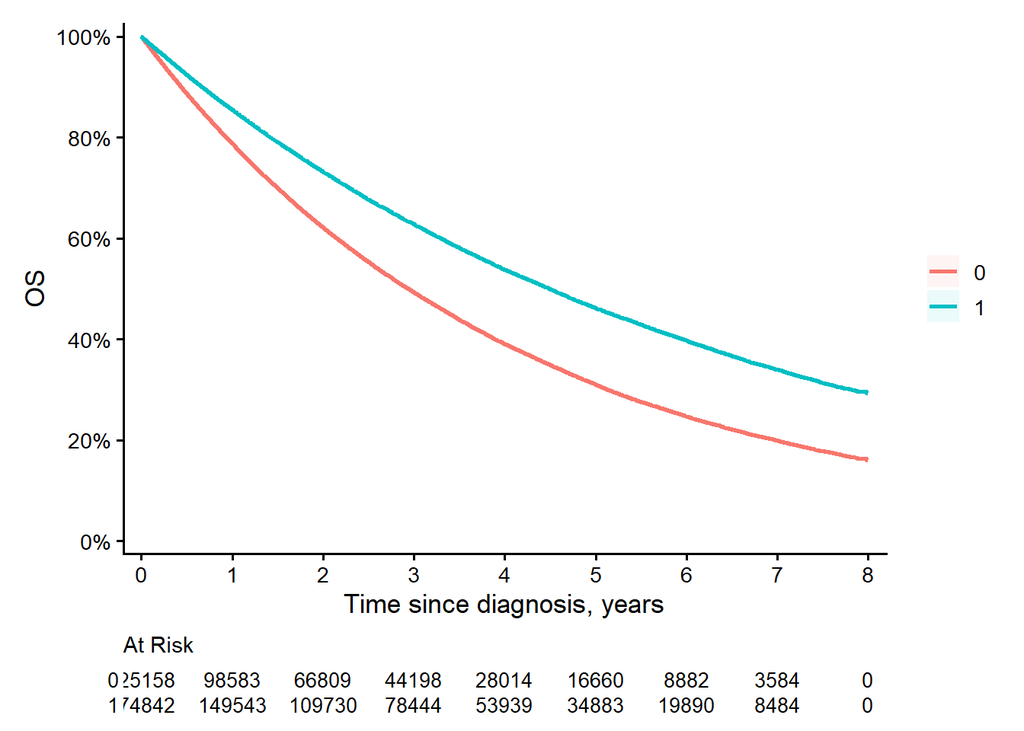

```r
fit <- survfit2(Surv(time, status) ~ surgery, data)
fit_cens <- survfit2(Surv(time, abs(status - 1)) ~ surgery, data)

ggsurvfit(fit, linewidth = 1) +
  add_confidence_interval(alpha = 0.08) +
  add_risktable(risktable_stats = "n.risk") +
  scale_ggsurvfit(
    y_scales = list(breaks = seq(0, 1, 0.2))
  ) +
  theme_classic(base_size = 13) +
  labs(x = "Time since diagnosis, years", y = "OS")
```

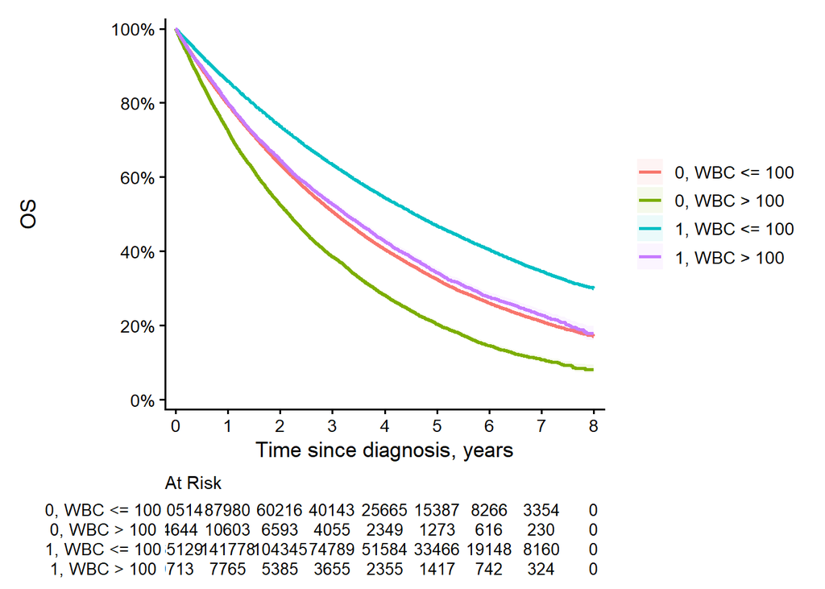

```r
data <- data %>%
  mutate(wbc_bin = case_when(wbc > 100 ~ "WBC > 100", TRUE ~ "WBC <= 100"))
fit <- survfit2(Surv(time, status) ~ surgery + wbc_bin, data)

ggsurvfit(fit, linewidth = 1) +
  add_confidence_interval(alpha = 0.08) +
  add_risktable(risktable_stats = "n.risk") +
  scale_ggsurvfit(
    y_scales = list(breaks = seq(0, 1, 0.2))
  ) +
  theme_classic(base_size = 13) +
  labs(x = "Time since diagnosis, years", y = "OS")
```

```r
tbl_survfit(
  fit_cens,
  probs = .5,
  statistic = "{estimate}",
  label_header = "median, years"
)
```

| **Characteristic** | median, years |
| --- | --- |
| surgery |  |
| 0 | 4.5 |
| 1 | 4.5 |

- **Задача 2.3: Логранговые тесты в подгруппах.** Проведите два логранговых теста. Сравните `surgery = 0` и `surgery = 1` отдельно среди пациентов с `wbc <= 100` и среди пациентов с `wbc > 100`. Для каждого теста приведите значение статистики и p-значение. Сформулируйте вывод.

```r
fit_data <- data %>% filter(wbc_bin == "WBC > 100")
fit_logrank <- survdiff(Surv(time, status) ~ surgery, fit_data)
tidy(fit_logrank)
```

```
# A tibble: 2 × 4
  surgery     N   obs   exp
  <chr>   <dbl> <dbl> <dbl>
1 0       14644 10394 8896.
2 1        9713  5643 7141.
```

```r
data.frame(
  Comparison = "surgery vs no surgery",
  p_value = round(fit_logrank$pvalue, 3)
) |>
  gt::gt()
```

| Comparison | p_value |
| --- | --- |
| surgery vs no surgery | 0 |

```r
fit_data <- data %>% filter(wbc_bin == "WBC <= 100")
fit_logrank <- survdiff(Surv(time, status) ~ surgery, fit_data)
data.frame(
  Comparison = "surgery vs no surgery",
  p_value = round(fit_logrank$pvalue, 3)
) |>
  gt::gt()
```

| Comparison | p_value |
| --- | --- |
| surgery vs no surgery | 0 |

## 3. Регрессия Кокса

- **Задача 3.1.1 Модель только с вмешательством.** Постройте модель Кокса для хирургического вмешательства `surgery`. Представьте коэффициенты регрессии, HR с 95% ДИ и p-value.

```r
fit <- coxph(Surv(time, status) ~ surgery, data)
tidy(fit, conf.int = TRUE, conf.level = 0.95, exp = TRUE) %>%
  gt::gt() %>%
  gt::fmt_number()
```

| term | estimate | std.error | statistic | p.value | conf.low | conf.high |
| --- | --- | --- | --- | --- | --- | --- |
| surgery | 0.66 | 0.01 | −82.85 | 0.00 | 0.65 | 0.67 |

- **Задача 3.1.2 Графическая проверка пропорциональности** Проверьте допущение о пропорциональности рисков построив на одном графике кривые в шкале cloglog.

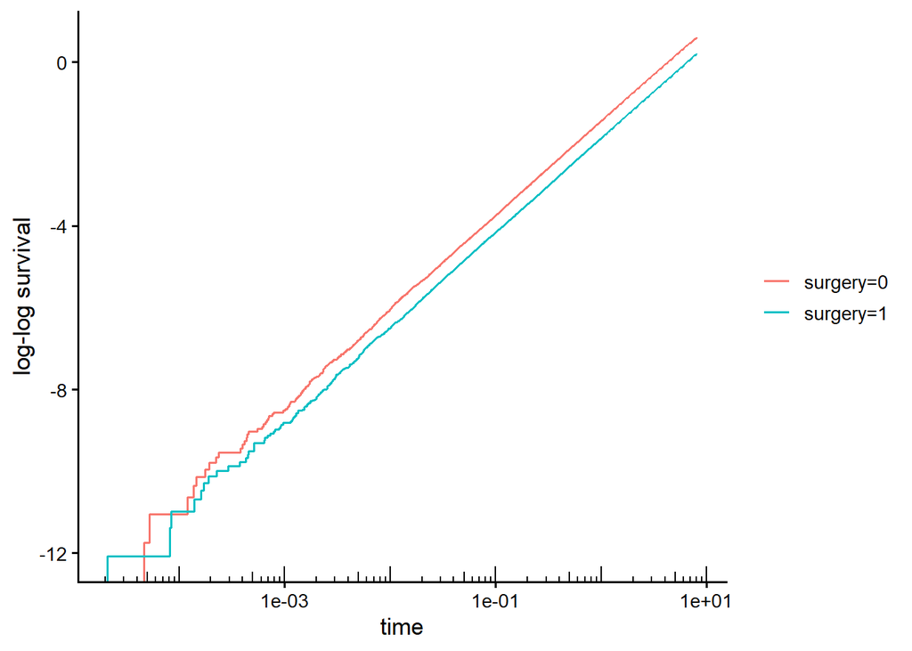

```r
fit <- survfit(Surv(time, status) ~ surgery, data)
ggsurvfit(fit, type = "cloglog") +
  labs(x = "time", y = "log-log survival") +
  scale_x_log10() +
  annotation_logticks(sides = "b") +
  theme_classic(base_size = 13)
```

**Задача 3.2.1. Модель с вмешательством и числом лейкоцитов.** Оцените модель Кокса с `surgery` и `wbc` в исходной шкале. Представьте коэффициенты регрессии, HR с 95% ДИ и p-value.

```r
fit <- coxph(Surv(time, status) ~ surgery + wbc, data)
tidy(fit, conf.int = TRUE, conf.level = 0.95, exp = TRUE) %>%
  gt::gt() %>%
  gt::fmt_number()
```

| term | estimate | std.error | statistic | p.value | conf.low | conf.high |
| --- | --- | --- | --- | --- | --- | --- |
| surgery | 0.67 | 0.01 | −78.48 | 0.00 | 0.67 | 0.68 |
| wbc | 1.00 | 0.00 | 65.63 | 0.00 | 1.00 | 1.00 |

**Задача 3.2.2. Выбор функциональной формы для `wbc`.** Исследуйте форму связи между wbc и log(HR) при учёте хирургического вмешательства. Определите, подходит ли линейная связь с wbc в исходной шкале. Укажите, в каком виде вы включите wbc в модель Кокса, и обоснуйте свой выбор результатами диагностики.

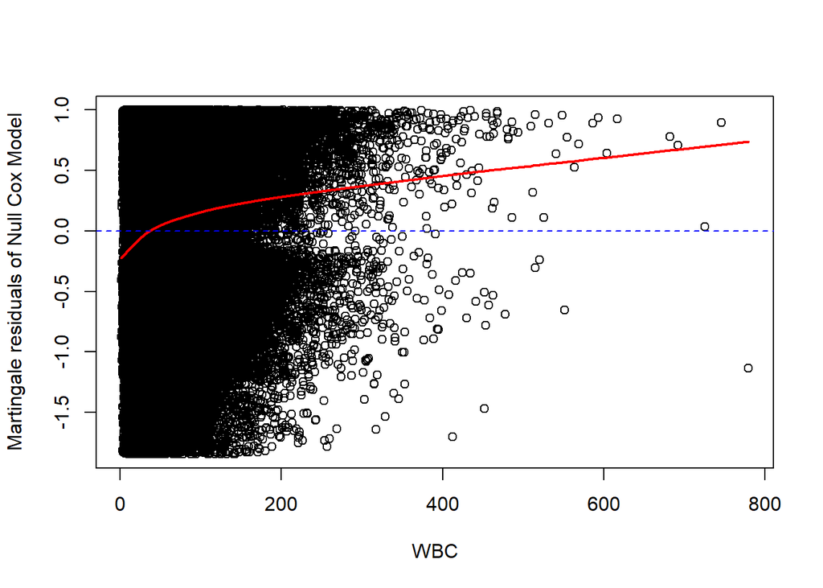

```r
fit <- coxph(Surv(time, status) ~ surgery, data)
mart_res <- residuals(fit, type = "martingale")
plot(
  data$wbc,
  mart_res,
  ylab = "Martingale residuals of Null Cox Model",
  xlab = "WBC"
)
lines(lowess(data$wbc, mart_res), col = "red", lwd = 2)
abline(h = 0, lty = 2, col = "blue")
```

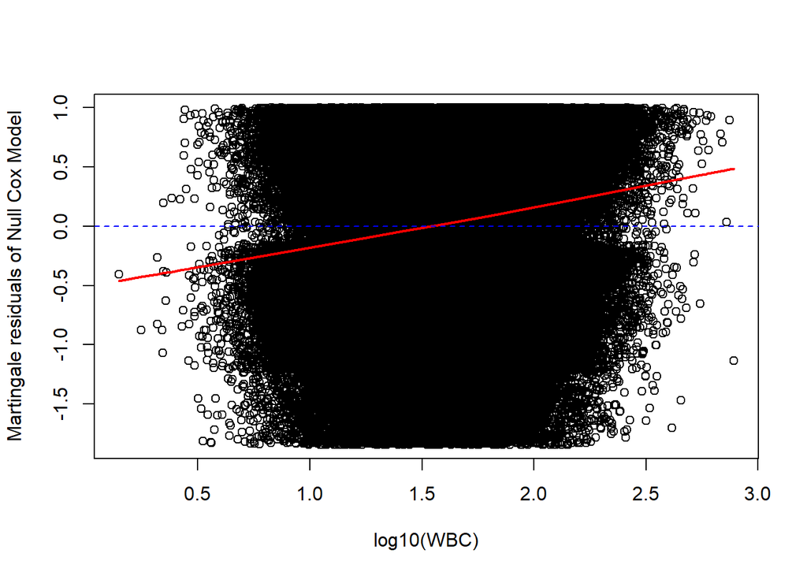

```r
plot(
  log10(data$wbc),
  mart_res,
  ylab = "Martingale residuals of Null Cox Model",
  xlab = "log10(WBC)"
)
lines(lowess(log10(data$wbc), mart_res), col = "red", lwd = 2)
abline(h = 0, lty = 2, col = "blue")
```

- **Задача 3.3 Проверка пропорциональности для модели с `surgery` и `wbc`.** Возьмите модель с той формой `wbc`, которую вы выбрали в пункте 3.2.2. Проверьте допущение пропорциональности рисков с помощью остатков Шёнфельда.

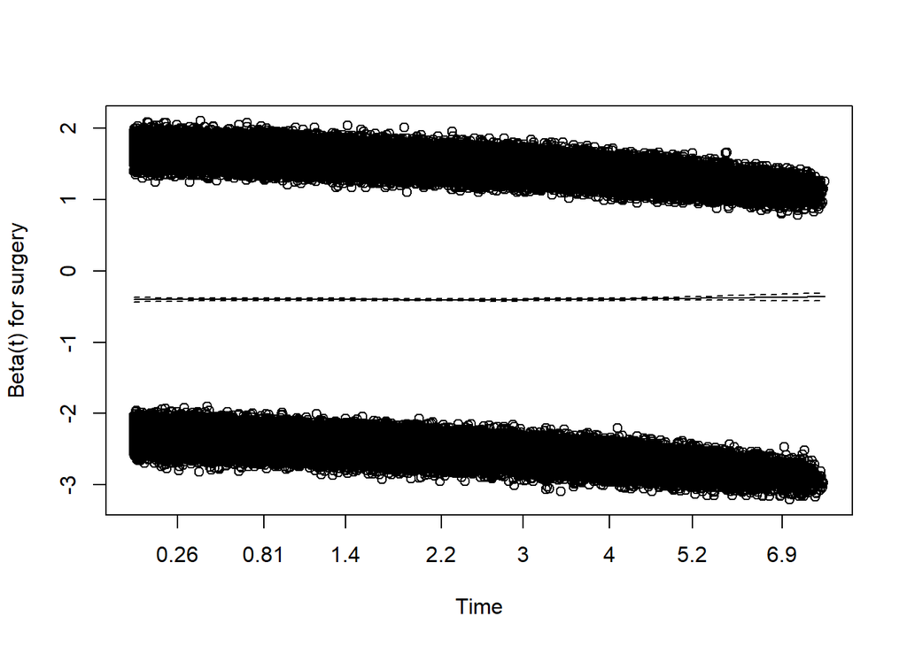

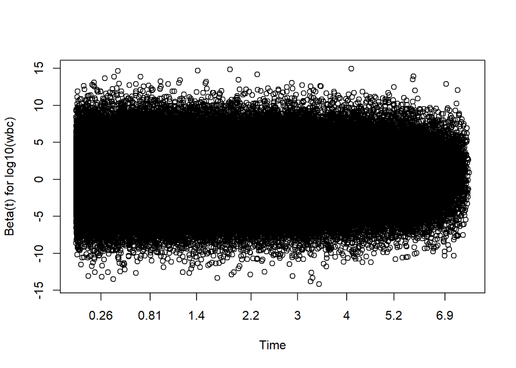

```r
zph_result <- cox.zph(
  coxph(Surv(time, status) ~ surgery + log10(wbc), data),
  transform = "km",
  terms = TRUE,
  singledf = FALSE,
  global = TRUE
)
plot(zph_result)
```

```r
print(zph_result)
```

```
           chisq df    p
surgery    0.563  1 0.45
log10(wbc) 1.056  1 0.30
GLOBAL     1.551  2 0.46
```

## 4. Итоговая модель

**Задача 4.** Запишите формулу итоговой модели и кратко обоснуйте выбор с учётом результатов диагностики функциональной формы и пропорциональности рисков. Оцените модель и представьте коэффициенты регрессии, HR с 95% ДИ и p-value. Проинтерпретируйте оценки модели - для каждого предиктора объясните, при каком его изменении, в какую сторону и как меняется HR.

```r
fit <- coxph(Surv(time, status) ~ surgery + log10(wbc), data)
tidy(fit, conf.int = TRUE, conf.level = 0.95, exp = TRUE) %>%
  gt::gt() %>%
  gt::fmt_number()
```

| term | estimate | std.error | statistic | p.value | conf.low | conf.high |
| --- | --- | --- | --- | --- | --- | --- |
| surgery | 0.67 | 0.01 | −79.39 | 0.00 | 0.66 | 0.68 |
| log10(wbc) | 1.80 | 0.01 | 68.97 | 0.00 | 1.77 | 1.83 |

- Вы завершили основную часть домашнего задания! Сохраните файл .qmd с кодом, графиками и выводами и соберите HTML-отчёт.

**Дополнительное задание** Вернитесь в файл генерации данных, установите n <- 300000 и заново запустите симуляцию с теми же параметрами. Посмотрите, как изменились оценки, ширина доверителльных интервалов. Сравните оценки, полученные на выборке 300 и 300000 наблюдений с параматерами, заданными при симуляции.